# Tugas Pertemuan 3 - Regresi dengan Peubah Lag

Raihana Asma Amani

## Impor Data

```r
data <- read_excel("C:/Users/raiha/Downloads/SEMESTER 5/MPDW/TUGAS INDIVIDU/PERTEMUAN 3/data.3.xlsx", sheet = 3)
str(data)
```

```
## tibble [50 × 4] (S3: tbl_df/tbl/data.frame)
##  $ t     : num [1:50] 1 2 3 4 5 6 7 8 9 10 ...
##  $ Yt    : num [1:50] 67418 68906 70707 75286 80080 ...
##  $ Y(t-1): num [1:50] NA 67418 68906 70707 75286 ...
##  $ Xt    : num [1:50] 61570 62482 63501 66685 70461 ...
```

```r
data
```

```
## # A tibble: 50 × 4
##        t    Yt `Y(t-1)`    Xt
##    <dbl> <dbl>    <dbl> <dbl>
##  1     1 67418       NA 61570
##  2     2 68906    67418 62482
##  3     3 70707    68906 63501
##  4     4 75286    70707 66685
##  5     5 80080    75286 70461
##  6     6 83022    80080 71366
##  7     7 85423    83022 73097
##  8     8 89979    85423 76677
##  9     9 91663    89979 76740
## 10    10 94594    91663 78857
## # ℹ 40 more rows
```

## Pembagian Data

```r
#SPLIT DATA
train<-data[1:40,]
test<-data[41:50,]
```

```r
#data time series
train.ts<-ts(train)
test.ts<-ts(test)
data.ts<-ts(data)
```

## Model Koyck

Model Koyck didasarkan pada asumsi bahwa semakin jauh jarak lag peubah independen dari periode sekarang maka semakin kecil pengaruh peubah lag terhadap peubah dependen.

Koyck mengusulkan suatu metode untuk menduga model dinamis distributed lag dengan mengasumsikan bahwa semua koefisien $\beta$ mempunyai tanda sama.

Model kyock merupakan jenis paling umum dari model infinite distributed lag dan juga dikenal sebagai geometric lag

$$y_t=a(1-\lambda)+\beta_0X_t+\beta_1Z_t+\lambda Y_{t-1}+V_t$$

dengan
$$V_t=u_t-\lambda
u_{t-1}$$

```r
#MODEL KOYCK
model.koyck <- koyckDlm(x = train$Xt, y = train$Yt, intercept = T)
summary(model.koyck)
```

```
##
## Call:
## "Y ~ (Intercept) + Y.1 + X.t"
##
## Residuals:
##      Min       1Q   Median       3Q      Max
## -12183.4  -2082.2    603.3   2743.0   6279.2
##
## Coefficients:
##              Estimate Std. Error t value Pr(>|t|)
## (Intercept) 7278.6328  3853.3410   1.889    0.067 .
## Y.1            0.7741     0.1191   6.500  1.5e-07 ***
## X.t            0.1897     0.1409   1.346    0.187
## ---
## Signif. codes:  0 '***' 0.001 '**' 0.01 '*' 0.05 '.' 0.1 ' ' 1
##
## Residual standard error: 4119 on 36 degrees of freedom
## Multiple R-Squared: 0.9432,  Adjusted R-squared:  0.94
## Wald test: 290.9 on 2 and 36 DF,  p-value: < 2.2e-16
##
## Diagnostic tests:
## NULL
##
##                             alpha      beta       phi
## Geometric coefficients:  32224.58 0.1897008 0.7741279
```

```r
AIC(model.koyck)
```

```
## [1] 764.7731
```

```r
BIC(model.koyck)
```

```
## [1] 771.4273
```

$$\hat{Y_t}=7278.6328+0.1897 X_t+0.7741Y_{t-1}$$

### Peramalan dan Akurasi

Berikut adalah hasil peramalan y untuk 10 periode kedepan menggunakan model koyck

```r
fore.koyck <- forecast(model = model.koyck, x=test$Xt, h=10)
fore.koyck
```

```
## $forecasts
##  [1] 82466.78 82654.75 82430.53 82131.56 81207.91 81190.22 81091.92 80245.64
##  [9] 80086.01 79176.69
##
## $call
## forecast.koyckDlm(model = model.koyck, x = test$Xt, h = 10)
##
## attr(,"class")
## [1] "forecast.koyckDlm" "dLagM"
```

```r
#mape data test/uji
(mape.koyck <- MAPE(fore.koyck$forecasts, test$Yt))
```

```
## [1] 0.03163323
```

```r
#akurasi data training
GoF(model.koyck)
```

```
##              n      MAE         MPE       MAPE      sMAPE      MASE      MSE
## model.koyck 39 3003.473 -0.00181816 0.02941345 0.02917325 0.7618397 15659061
##                MRAE     GMRAE
## model.koyck 1.24687 0.6707584
```

MAPE data train = 0.02941345 . MAPE data uji = 0.03163323 . Hal tersebut menunjukkan model yang sangat baik karena nilai MAPE kurang sari 10%.

###### Regression with Distributed Lag

### Pemodelan (Lag=2)

```r
model.dlm <- dlm(x = train$Xt,y = train$Yt , q = 2)
summary(model.dlm)
```

```
##
## Call:
## lm(formula = model.formula, data = design)
##
## Residuals:
##     Min      1Q  Median      3Q     Max
## -9821.4 -2094.9   170.5  3095.0  7586.0
##
## Coefficients:
##              Estimate Std. Error t value Pr(>|t|)
## (Intercept) 1.395e+04  3.907e+03   3.570  0.00109 **
## x.t         9.163e-01  1.617e-01   5.667 2.33e-06 ***
## x.1         4.696e-02  2.519e-01   0.186  0.85321
## x.2         8.867e-02  1.629e-01   0.544  0.58976
## ---
## Signif. codes:  0 '***' 0.001 '**' 0.01 '*' 0.05 '.' 0.1 ' ' 1
##
## Residual standard error: 4201 on 34 degrees of freedom
## Multiple R-squared:  0.939,  Adjusted R-squared:  0.9336
## F-statistic: 174.3 on 3 and 34 DF,  p-value: < 2.2e-16
##
## AIC and BIC values for the model:
##       AIC      BIC
## 1 747.684 755.8719
```

```r
AIC(model.dlm)
```

```
## [1] 747.684
```

```r
BIC(model.dlm)
```

```
## [1] 755.8719
```

### Peramalan dan Akurasi

Berikut merupakan hasil peramalan $y$ untuk 10 periode kedepan

```r
fore.dlm <- forecast(model = model.dlm, x=test$Xt, h=10)
fore.dlm
```

```
## $forecasts
##  [1] 74720.58 77554.83 75847.84 75436.89 71889.48 75027.82 74468.20 71053.07
##  [9] 73216.24 69183.61
##
## $call
## forecast.dlm(model = model.dlm, x = test$Xt, h = 10)
##
## attr(,"class")
## [1] "forecast.dlm" "dLagM"
```

```r
#mape uji
(mape.dlm <- MAPE(fore.dlm$forecasts, test$Yt))
```

```
## [1] 0.117714
```

```r
#akurasi data training
GoF(model.dlm)
```

```
##            n      MAE          MPE       MAPE      sMAPE     MASE      MSE
## model.dlm 38 3142.888 -0.001818875 0.03545652 0.03521093 0.785669 15789564
##               MRAE     GMRAE
## model.dlm 2.187527 0.6550112
```

MAPE data train = 0.03545652  
Hal tersebut menunjukkan model yang sangat baik karena nilai MAPE kurang sari 10%.

### *Lag* Optimum

```r
#penentuan lag optimum
finiteDLMauto(formula = Yt ~ Xt,
              data = data.frame(train), q.min = 1, q.max = 6,
              model.type = "dlm", error.type = "AIC", trace = FALSE)
```

```
##   q - k    MASE      AIC      BIC   GMRAE   MBRAE R.Adj.Sq    Ljung-Box
## 6     6 0.52935 652.4503 666.1876 0.48891 0.60631  0.95725 3.909367e-06
```

Berdasarkan output tersebut, lag optimum didapatkan ketika lag=6. Selanjutnya dilakukan pemodelan untuk lag=6

```r
#model dlm dengan lag optimum
model.dlm2 <- dlm(x = train$Xt,y = train$Yt , q = 6)
summary(model.dlm2)
```

```
##
## Call:
## lm(formula = model.formula, data = design)
##
## Residuals:
##     Min      1Q  Median      3Q     Max
## -7503.2 -1741.4   405.9  1774.0  4263.4
##
## Coefficients:
##               Estimate Std. Error t value Pr(>|t|)
## (Intercept)  2.203e+04  3.830e+03   5.751 4.69e-06 ***
## x.t          9.745e-01  1.293e-01   7.538 5.29e-08 ***
## x.1          5.442e-02  1.958e-01   0.278    0.783
## x.2         -2.514e-02  1.951e-01  -0.129    0.898
## x.3         -8.925e-03  1.992e-01  -0.045    0.965
## x.4         -3.663e-02  1.956e-01  -0.187    0.853
## x.5         -7.092e-02  1.969e-01  -0.360    0.722
## x.6          7.968e-02  1.308e-01   0.609    0.548
## ---
## Signif. codes:  0 '***' 0.001 '**' 0.01 '*' 0.05 '.' 0.1 ' ' 1
##
## Residual standard error: 3119 on 26 degrees of freedom
## Multiple R-squared:  0.9663, Adjusted R-squared:  0.9573
## F-statistic: 106.6 on 7 and 26 DF,  p-value: < 2.2e-16
##
## AIC and BIC values for the model:
##        AIC      BIC
## 1 652.4504 666.1876
```

```r
AIC(model.dlm2)
```

```
## [1] 652.4504
```

```r
BIC(model.dlm2)
```

```
## [1] 666.1876
```

$$\hat{Y_t}=22030+0.9745X_t+...+0.07968X_{t-6}$$

Adapun hasil peramalan 10 periode kedepan menggunakan model tersebut adalah sebagai berikut

```r
#peramalan dan akurasi
fore.dlm2 <- forecast(model = model.dlm2, x=test$Xt, h=10)
```

```r
#mape uji
(mape.dlm2<- MAPE(fore.dlm2$forecasts, test$Yt))
```

```
## [1] 0.07972351
```

```r
#akurasi data training
GoF(model.dlm2)
```

```
##             n     MAE           MPE       MAPE      sMAPE      MASE     MSE
## model.dlm2 34 2138.16 -0.0005101127 0.02247708 0.02236065 0.5293508 7440343
##                MRAE     GMRAE
## model.dlm2 1.847789 0.4889076
```

MAPE data train = 0.02247708 . MAPE data uji = 0.07972351 . Model tersebut merupakan model yang sangat baik dengan nilai MAPE yang kurang dari 10%.

## Model Autoregressive

Peubah dependen dipengaruhi oleh peubah independen pada waktu sekarang, serta dipengaruhi juga oleh peubah dependen itu sendiri pada satu waktu yang lalu maka model tersebut disebut *autoregressive* (Gujarati 2004).

### Pemodelan

Dengan $p$ adalah integer yang mewakili panjang *lag* yang terbatas dan $q$ adalah integer yang merepresentasikan ordo dari proses *autoregressive*.

```r
model.ardl <- ardlDlm(formula = Yt ~ Xt,
                         data = train,p = 1 , q = 1)
summary(model.ardl)
```

```
##
## Time series regression with "ts" data:
## Start = 2, End = 40
##
## Call:
## dynlm(formula = as.formula(model.text), data = data)
##
## Residuals:
##      Min       1Q   Median       3Q      Max
## -1616.40  -419.00   -83.49   634.91  1043.39
##
## Coefficients:
##               Estimate Std. Error t value Pr(>|t|)
## (Intercept) 2933.58423  666.69538    4.40 9.67e-05 ***
## Xt.t           1.11765    0.02664   41.95  < 2e-16 ***
## Xt.1          -1.12535    0.04343  -25.91  < 2e-16 ***
## Yt.1           0.98151    0.02604   37.70  < 2e-16 ***
## ---
## Signif. codes:  0 '***' 0.001 '**' 0.01 '*' 0.05 '.' 0.1 ' ' 1
##
## Residual standard error: 699.4 on 35 degrees of freedom
## Multiple R-squared:  0.9984, Adjusted R-squared:  0.9983
## F-statistic:  7312 on 3 and 35 DF,  p-value: < 2.2e-16
```

```r
AIC(model.ardl)
```

```
## [1] 627.3794
```

```r
BIC(model.ardl)
```

```
## [1] 635.6972
```

$$\hat{Y}=2933.58423+1.11765X_t-1.12535 X_{t-1}+0.98151Y_{t-1}$$

### Peramalan dan Akurasi

```r
fore.ardl <- forecast(model = model.ardl, x=test$Xt, h=10)
fore.ardl
```

```
## $forecasts
##  [1] 83047.94 87610.85 86278.46 86425.24 83234.85 88318.35 88672.60 84984.53
##  [9] 88852.89 85080.99
##
## $call
## forecast.ardlDlm(model = model.ardl, x = test$Xt, h = 10)
##
## attr(,"class")
## [1] "forecast.ardlDlm" "dLagM"
```

Data di atas merupakan hasil peramalan untuk 10 periode ke depan menggunakan Model Autoregressive dengan $p=1$ dan $q=1$.

```r
mape.ardl <- MAPE(fore.ardl$forecasts, test$Yt)
mape.ardl
```

```
## [1] 0.0311339
```

```r
#akurasi data training
GoF(model.ardl)
```

```
##             n      MAE           MPE        MAPE       sMAPE      MASE      MSE
## model.ardl 39 552.0758 -0.0001060252 0.005636048 0.005635023 0.1400356 439048.2
##                 MRAE     GMRAE
## model.ardl 0.4739761 0.1442599
```

Berdasarkan akurasi di atas, terlihat bahwa nilai MAPE keduanya (MAPE model Koyck dan Autoregressive) tidak jauh berbeda. Artinya, model regresi dengan distribusi lag ini tidak `overfitted` atau `underfitted`

### *Lag* Optimum

```r
#penentuan lag optimum
model.ardl.opt <- ardlBoundOrders(data = data.frame(data), ic = "AIC",
                                  formula = Yt ~ Xt )
min_p=c()
for(i in 1:6){
  min_p[i]=min(model.ardl.opt$Stat.table[[i]])
}
q_opt=which(min_p==min(min_p, na.rm = TRUE))
p_opt=which(model.ardl.opt$Stat.table[[q_opt]] ==
              min(model.ardl.opt$Stat.table[[q_opt]], na.rm = TRUE))
data.frame("q_optimum" = q_opt, "p_optimum" = p_opt,
           "AIC"=model.ardl.opt$min.Stat)
```

```
##   q_optimum p_optimum      AIC
## 1         4        15 474.7408
```

Dari tabel di atas, dapat terlihat bahwa nilai AIC terendah didapat ketika $p=15$ dan $q=4$, yaitu sebesar `474.7408`. Artinya, model autoregressive optimum didapat ketika $p=15$ dan $q=4$.

Selanjutnya dapat dilakukan pemodelan dengan nilai $p$ dan $q$ optimum seperti inisialisasi di langkah sebelumnya.

```r
model.ardl2 <- ardlDlm(formula = Yt ~ Xt,
                         data = train,p = 15 , q = 4)
summary(model.ardl2)
```

```
##
## Time series regression with "ts" data:
## Start = 16, End = 40
##
## Call:
## dynlm(formula = as.formula(model.text), data = data)
##
## Residuals:
##       16       17       18       19       20       21       22       23
##   -5.635   11.439  -26.039  141.585  -19.286  -23.994 -150.839    9.480
##       24       25       26       27       28       29       30       31
##   49.829  103.260  -97.247  -62.165  -32.184  109.961    7.916   53.561
##       32       33       34       35       36       37       38       39
##  -71.774  -25.023   36.814   62.316  -46.611   24.354 -108.981  104.175
##       40
##  -44.913
##
## Coefficients:
##               Estimate Std. Error t value Pr(>|t|)
## (Intercept)  9.776e+04  1.865e+04   5.241  0.00633 **
## Xt.t         1.002e+00  1.748e-02  57.348 5.54e-07 ***
## Xt.1         5.839e-01  3.012e-01   1.939  0.12457
## Xt.2         9.855e-01  1.517e-01   6.497  0.00289 **
## Xt.3         1.292e-01  3.887e-01   0.332  0.75630
## Xt.4        -1.474e-01  2.182e-01  -0.676  0.53639
## Xt.5        -1.220e-01  2.918e-02  -4.181  0.01391 *
## Xt.6        -1.367e-01  2.629e-02  -5.200  0.00652 **
## Xt.7        -1.341e-01  3.551e-02  -3.778  0.01947 *
## Xt.8        -6.075e-02  3.539e-02  -1.717  0.16120
## Xt.9         1.691e-02  2.007e-02   0.843  0.44687
## Xt.10       -3.247e-02  1.712e-02  -1.897  0.13072
## Xt.11       -4.002e-02  3.047e-02  -1.313  0.25939
## Xt.12       -1.357e-03  1.874e-02  -0.072  0.94575
## Xt.13        2.765e-03  1.669e-02   0.166  0.87643
## Xt.14        1.614e-02  1.751e-02   0.922  0.40886
## Xt.15       -3.803e-02  1.589e-02  -2.393  0.07489 .
## Yt.1        -5.905e-01  2.879e-01  -2.051  0.10956
## Yt.2        -9.070e-01  1.356e-01  -6.691  0.00260 **
## Yt.3        -1.294e-01  3.469e-01  -0.373  0.72814
## Yt.4         7.476e-02  1.911e-01   0.391  0.71554
## ---
## Signif. codes:  0 '***' 0.001 '**' 0.01 '*' 0.05 '.' 0.1 ' ' 1
##
## Residual standard error: 177.3 on 4 degrees of freedom
## Multiple R-squared:      1,  Adjusted R-squared:  0.9999
## F-statistic:  9761 on 20 and 4 DF,  p-value: 2.309e-08
```

##### Pemodelan DLM & ARDL dengan Library dynlm

```r
#sama dengan model dlm q=1
cons_lm1 <- dynlm(Yt ~ Xt+L(Xt),data = train.ts)
#sama dengan model ardl p=1 q=0
cons_lm2 <- dynlm(Yt ~ Xt+L(Yt),data = train.ts)
#sama dengan ardl p=1 q=1
cons_lm3 <- dynlm(Yt ~ Xt+L(Xt)+L(Yt),data = train.ts)
#sama dengan dlm p=2
cons_lm4 <- dynlm(Yt ~ Xt+L(Xt)+L(Xt,2),data = train.ts)
```

### Ringkasan Model

```r
summary(cons_lm1)
```

```
##
## Time series regression with "ts" data:
## Start = 2, End = 40
##
## Call:
## dynlm(formula = Yt ~ Xt + L(Xt), data = train.ts)
##
## Residuals:
##     Min      1Q  Median      3Q     Max
## -9990.8 -1913.9   -58.1  3194.0  8140.9
##
## Coefficients:
##              Estimate Std. Error t value Pr(>|t|)
## (Intercept) 1.218e+04  3.943e+03   3.090  0.00385 **
## Xt          8.880e-01  1.649e-01   5.383 4.64e-06 ***
## L(Xt)       1.824e-01  1.662e-01   1.098  0.27969
## ---
## Signif. codes:  0 '***' 0.001 '**' 0.01 '*' 0.05 '.' 0.1 ' ' 1
##
## Residual standard error: 4449 on 36 degrees of freedom
## Multiple R-squared:  0.9337, Adjusted R-squared:   0.93
## F-statistic: 253.6 on 2 and 36 DF,  p-value: < 2.2e-16
```

```r
summary(cons_lm2)
```

```
##
## Time series regression with "ts" data:
## Start = 2, End = 40
##
## Call:
## dynlm(formula = Yt ~ Xt + L(Yt), data = train.ts)
##
## Residuals:
##     Min      1Q  Median      3Q     Max
## -7720.0 -1948.1   284.2  2634.8  4880.9
##
## Coefficients:
##              Estimate Std. Error t value Pr(>|t|)
## (Intercept) 6.363e+03  2.895e+03   2.198   0.0344 *
## Xt          6.041e-01  7.887e-02   7.660 4.56e-09 ***
## L(Yt)       4.427e-01  6.939e-02   6.379 2.17e-07 ***
## ---
## Signif. codes:  0 '***' 0.001 '**' 0.01 '*' 0.05 '.' 0.1 ' ' 1
##
## Residual standard error: 3098 on 36 degrees of freedom
## Multiple R-squared:  0.9678, Adjusted R-squared:  0.9661
## F-statistic: 541.8 on 2 and 36 DF,  p-value: < 2.2e-16
```

```r
summary(cons_lm3)
```

```
##
## Time series regression with "ts" data:
## Start = 2, End = 40
##
## Call:
## dynlm(formula = Yt ~ Xt + L(Xt) + L(Yt), data = train.ts)
##
## Residuals:
##      Min       1Q   Median       3Q      Max
## -1616.40  -419.00   -83.49   634.91  1043.39
##
## Coefficients:
##               Estimate Std. Error t value Pr(>|t|)
## (Intercept) 2933.58423  666.69538    4.40 9.67e-05 ***
## Xt             1.11765    0.02664   41.95  < 2e-16 ***
## L(Xt)         -1.12535    0.04343  -25.91  < 2e-16 ***
## L(Yt)          0.98151    0.02604   37.70  < 2e-16 ***
## ---
## Signif. codes:  0 '***' 0.001 '**' 0.01 '*' 0.05 '.' 0.1 ' ' 1
##
## Residual standard error: 699.4 on 35 degrees of freedom
## Multiple R-squared:  0.9984, Adjusted R-squared:  0.9983
## F-statistic:  7312 on 3 and 35 DF,  p-value: < 2.2e-16
```

```r
summary(cons_lm4)
```

```
##
## Time series regression with "ts" data:
## Start = 3, End = 40
##
## Call:
## dynlm(formula = Yt ~ Xt + L(Xt) + L(Xt, 2), data = train.ts)
##
## Residuals:
##     Min      1Q  Median      3Q     Max
## -9821.4 -2094.9   170.5  3095.0  7586.0
##
## Coefficients:
##              Estimate Std. Error t value Pr(>|t|)
## (Intercept) 1.395e+04  3.907e+03   3.570  0.00109 **
## Xt          9.163e-01  1.617e-01   5.667 2.33e-06 ***
## L(Xt)       4.696e-02  2.519e-01   0.186  0.85321
## L(Xt, 2)    8.867e-02  1.629e-01   0.544  0.58976
## ---
## Signif. codes:  0 '***' 0.001 '**' 0.01 '*' 0.05 '.' 0.1 ' ' 1
##
## Residual standard error: 4201 on 34 degrees of freedom
## Multiple R-squared:  0.939,  Adjusted R-squared:  0.9336
## F-statistic: 174.3 on 3 and 34 DF,  p-value: < 2.2e-16
```

### SSE

```r
deviance(cons_lm1)
```

```
## [1] 712440010
```

```r
deviance(cons_lm2)
```

```
## [1] 345608348
```

```r
deviance(cons_lm3)
```

```
## [1] 17122881
```

```r
deviance(cons_lm4)
```

```
## [1] 600003423
```

SSE paling kecil dimiliki oleh model cons_lm3 dengan nilai 17122881.

### Uji Diagnostik

```r
#uji model
if(require("lmtest")) encomptest(cons_lm1, cons_lm2)
```

```
## Encompassing test
##
## Model 1: Yt ~ Xt + L(Xt)
## Model 2: Yt ~ Xt + L(Yt)
## Model E: Yt ~ Xt + L(Xt) + L(Yt)
##           Res.Df Df       F    Pr(>F)
## M1 vs. ME     35 -1 1421.26 < 2.2e-16 ***
## M2 vs. ME     35 -1  671.44 < 2.2e-16 ***
## ---
## Signif. codes:  0 '***' 0.001 '**' 0.01 '*' 0.05 '.' 0.1 ' ' 1
```

#### Autokorelasi

```r
#durbin watson
dwtest(cons_lm1)
```

```
##
##  Durbin-Watson test
##
## data:  cons_lm1
## DW = 0.11249, p-value < 2.2e-16
## alternative hypothesis: true autocorrelation is greater than 0
```

```r
dwtest(cons_lm2)
```

```
##
##  Durbin-Watson test
##
## data:  cons_lm2
## DW = 0.85667, p-value = 8.044e-06
## alternative hypothesis: true autocorrelation is greater than 0
```

```r
dwtest(cons_lm3)
```

```
##
##  Durbin-Watson test
##
## data:  cons_lm3
## DW = 1.3371, p-value = 0.004828
## alternative hypothesis: true autocorrelation is greater than 0
```

```r
dwtest(cons_lm4)
```

```
##
##  Durbin-Watson test
##
## data:  cons_lm4
## DW = 0.10418, p-value < 2.2e-16
## alternative hypothesis: true autocorrelation is greater than 0
```

#### Heterogenitas

```r
bptest(cons_lm1)
```

```
##
##  studentized Breusch-Pagan test
##
## data:  cons_lm1
## BP = 17.407, df = 2, p-value = 0.000166
```

```r
bptest(cons_lm2)
```

```
##
##  studentized Breusch-Pagan test
##
## data:  cons_lm2
## BP = 4.9321, df = 2, p-value = 0.08492
```

```r
bptest(cons_lm3)
```

```
##
##  studentized Breusch-Pagan test
##
## data:  cons_lm3
## BP = 1.3306, df = 3, p-value = 0.7219
```

```r
bptest(cons_lm4)
```

```
##
##  studentized Breusch-Pagan test
##
## data:  cons_lm4
## BP = 15.079, df = 3, p-value = 0.00175
```

Uji Breusch-Pagan menunjukkan nilai p−value untuk model cons_lm2 = 0.08492 dan cons_lm3 = 0.7219 dapat dikatakan bahwa model tersebut memiliki ragam sisaan yang homogen, sedangkan model sisanya tidak homogen (melanggar asumsi).

#### Kenormalan

```r
shapiro.test(residuals(cons_lm1))
```

```
##
##  Shapiro-Wilk normality test
##
## data:  residuals(cons_lm1)
## W = 0.97715, p-value = 0.6005
```

```r
shapiro.test(residuals(cons_lm2))
```

```
##
##  Shapiro-Wilk normality test
##
## data:  residuals(cons_lm2)
## W = 0.97028, p-value = 0.383
```

```r
shapiro.test(residuals(cons_lm3))
```

```
##
##  Shapiro-Wilk normality test
##
## data:  residuals(cons_lm3)
## W = 0.96501, p-value = 0.2609
```

```r
shapiro.test(residuals(cons_lm4))
```

```
##
##  Shapiro-Wilk normality test
##
## data:  residuals(cons_lm4)
## W = 0.97608, p-value = 0.5793
```

Uji Shapiro-Wilk pada semua model menghasilkan nilai p−value > 0.05 , sehingga semua model memiliki sisaan yang menyebar normal (memenuhi asumsi normalitas).

## Perbandingan Model

```r
akurasi <- matrix(c(mape.koyck, mape.dlm, mape.dlm2, mape.ardl))
row.names(akurasi)<- c("Koyck","DLM 1","DLM 2","Autoregressive")
colnames(akurasi) <- c("MAPE")
akurasi
```

```
##                      MAPE
## Koyck          0.03163323
## DLM 1          0.11771397
## DLM 2          0.07972351
## Autoregressive 0.03113390
```

### Plot

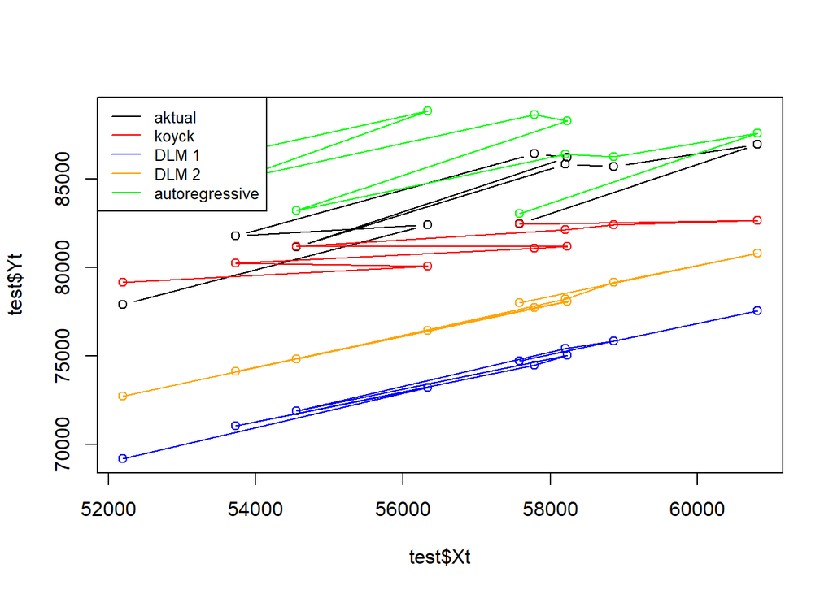

```r
# Tentukan ylim sesuai range data
ylim_range <- range(test$Yt, fore.koyck$forecasts, fore.dlm$forecasts, fore.dlm2$forecasts, fore.ardl$forecasts)

# Plot data aktual
plot(test$Xt, test$Yt, type="b", col="black", ylim=ylim_range)

# Tambahkan prediksi model Koyck
points(test$Xt, fore.koyck$forecasts, col="red")
lines(test$Xt, fore.koyck$forecasts, col="red")

# Tambahkan prediksi DLM 1
points(test$Xt, fore.dlm$forecasts, col="blue")
lines(test$Xt, fore.dlm$forecasts, col="blue")

# Tambahkan prediksi DLM 2
points(test$Xt, fore.dlm2$forecasts, col="orange")
lines(test$Xt, fore.dlm2$forecasts, col="orange")

# Tambahkan prediksi ARDL
points(test$Xt, fore.ardl$forecasts, col="green")
lines(test$Xt, fore.ardl$forecasts, col="green")

# Buat legenda
legend("topleft", c("aktual", "koyck", "DLM 1", "DLM 2", "autoregressive"),
       lty=1, col=c("black", "red", "blue", "orange", "green"), cex=0.8)
```

Berdasarkan plot tersebut, terlihat bahwa plot yang paling mendekati data aktualnya adalah Model Autoregressive, sehingga dapat disimpulkan model terbaik dalam hal ini adalah model regresi autoregressive.